# 🎓 Zdrowie psychiczne studentów uniwersytetu - analiza bazy danych 🎓

### 🖋️ Liliana Kołczyk 🖋️

*Zestaw danych zebrano w badaniu ankietowym przeprowadzonym za pomocą formularzy Google wśród studentów Uniwersytetu Malezyjskiego, aby zbadać ich obecną sytuację akademicką i zdrowie psychiczne.*

*Kolumny: • Timestamp – Data rejestracji danych. • Gender – Płeć osoby (np. Female = kobieta, Male = mężczyzna). • Age – Wiek osoby w latach. • Course – Kierunek studiów (np. Biotechnology – biotechnologia). • YearOfStudy – Rok studiów (np. Year 3 – trzeci rok). • CGPA – Cumulative Grade Point Average – średnia ocen studenta, wskazująca jego ogólne osiągnięcia akademickie. • Depression – Obecność depresji (1 – tak, 0 – nie). • Anxiety – Obecność lęków (1 – tak, 0 – nie). • PanicAttack – Obecność ataków paniki (1 – tak, 0 – nie). • SpecialistTreatment – Czy osoba otrzymuje specjalistyczne leczenie (1 – tak, 0 – nie). • SymptomFrequency_Last7Days – Częstotliwość występowania objawów w ciągu ostatnich 7 dni (na skali od 0 do 7). • HasMentalHealthSupport – Czy osoba ma wsparcie w zakresie zdrowia psychicznego (1 – tak, 0 – nie). • SleepQuality – Jakość snu (na skali od 1 do 5, gdzie 1 oznacza bardzo słabą jakość, a 5 bardzo dobrą). • StudyStressLevel – Poziom stresu związany ze studiami (na skali od 1 do 5). • StudyHoursPerWeek – Liczba godzin poświęconych na naukę w tygodniu. • AcademicEngagement – Poziom zaangażowania w naukę (na skali od 1 do 5, gdzie 1 oznacza brak zaangażowania, a 5 pełne zaangażowanie).*

### Importowanie niezbędnych bibliotek:

```python
import pandas as pd
import numpy as np
import seaborn as sns
import matplotlib.pyplot as plt
from sklearn.model_selection import train_test_split
from sklearn.linear_model import LinearRegression
from sklearn.metrics import mean_squared_error
import statsmodels.api as sm
```

### Wczytanie danych bazy z pliku CSV:

```python
df = pd.read_csv('mentalhealth_dataset.csv')
```

### Wyświetlenie pierwszych kilku wierszy:

```python
df.head()
```

|  | Timestamp | Gender | Age | Course | YearOfStudy | CGPA | Depression | Anxiety | PanicAttack | SpecialistTreatment | SymptomFrequency_Last7Days | HasMentalHealthSupport | SleepQuality | StudyStressLevel | StudyHoursPerWeek | AcademicEngagement |
| --- | --- | --- | --- | --- | --- | --- | --- | --- | --- | --- | --- | --- | --- | --- | --- | --- |
| 0 | 13/7/2020 | Female | 24 | Biotechnology | Year 3 | 2.38 | 1 | 0 | 0 | 0 | 5 | 0 | 4 | 5 | 8 | 2 |
| 1 | 13/7/2020 | Female | 18 | Biotechnology | Year 3 | 4.00 | 0 | 1 | 0 | 0 | 0 | 0 | 4 | 4 | 13 | 5 |
| 2 | 13/7/2020 | Female | 25 | Biotechnology | Year 3 | 3.68 | 0 | 0 | 1 | 0 | 3 | 0 | 1 | 2 | 13 | 1 |
| 3 | 13/7/2020 | Female | 18 | Engineering | year 4 | 4.00 | 0 | 0 | 0 | 0 | 3 | 0 | 5 | 1 | 19 | 2 |
| 4 | 13/7/2020 | Female | 20 | Engineering | year 4 | 2.00 | 1 | 1 | 0 | 0 | 0 | 0 | 2 | 4 | 3 | 2 |

### Sprawdzenie struktury danych:

```python
df.info()
```

```
<class 'pandas.core.frame.DataFrame'>
RangeIndex: 1000 entries, 0 to 999
Data columns (total 16 columns):
 #   Column                      Non-Null Count  Dtype
---  ------                      --------------  -----
 0   Timestamp                   1000 non-null   object
 1   Gender                      1000 non-null   object
 2   Age                         1000 non-null   int64
 3   Course                      1000 non-null   object
 4   YearOfStudy                 1000 non-null   object
 5   CGPA                        1000 non-null   float64
 6   Depression                  1000 non-null   int64
 7   Anxiety                     1000 non-null   int64
 8   PanicAttack                 1000 non-null   int64
 9   SpecialistTreatment         1000 non-null   int64
 10  SymptomFrequency_Last7Days  1000 non-null   int64
 11  HasMentalHealthSupport      1000 non-null   int64
 12  SleepQuality                1000 non-null   int64
 13  StudyStressLevel            1000 non-null   int64
 14  StudyHoursPerWeek           1000 non-null   int64
 15  AcademicEngagement          1000 non-null   int64
dtypes: float64(1), int64(11), object(4)
memory usage: 125.1+ KB
```

**Odp:** *Zbiór danych zawiera 1000 wpisów (wierszy) oraz 16 kolumn. Typy danych są zróżnicowane: od liczb całkowitych (int64), przez liczby zmiennoprzecinkowe (float64), po dane tekstowe (object).*

### Sprawdzanie brakujących danych:

```python
df.isna().sum()
```

```
Timestamp                     0
Gender                        0
Age                           0
Course                        0
YearOfStudy                   0
CGPA                          0
Depression                    0
Anxiety                       0
PanicAttack                   0
SpecialistTreatment           0
SymptomFrequency_Last7Days    0
HasMentalHealthSupport        0
SleepQuality                  0
StudyStressLevel              0
StudyHoursPerWeek             0
AcademicEngagement            0
dtype: int64
```

**Odp:** *Jak widać, nie ma brakujących danych w żadnej z kolumn. To oznacza, że baza danych jest kompletna pod względem wartości.*

### Sprawdzenie, czy zakresy danych są w rozsądnych wartościach:

```python
print("Zakresy danych:")
print(f"Minimalny wiek: {df['Age'].min()}, Maksymalny wiek: {df['Age'].max()}")
print(f"Minimalny CGPA: {df['CGPA'].min()}, Maksymalny CGPA: {df['CGPA'].max()}")
print(f"Minimalna liczba godzin nauki na tydzień: {df['StudyHoursPerWeek'].min()}, Maksymalna liczba godzin nauki na tydzień: {df['StudyHoursPerWeek'].max()}")
```

```
Zakresy danych:
Minimalny wiek: 18, Maksymalny wiek: 25
Minimalny CGPA: 2.0, Maksymalny CGPA: 4.0
Minimalna liczba godzin nauki na tydzień: 1, Maksymalna liczba godzin nauki na tydzień: 19
```

**Odp:** *Wiek: Minimalny wiek wynosi 18 lat, a maksymalny 25 lat. To typowy przedział wiekowy dla studentów, więc jest to spójne z danymi.*

*CGPA: Średnia ocen waha się od 2.0 do 4.0, co jest zgodne z popularną skalą ocen na uniwersytetach, gdzie 4.0 to najlepszy wynik, a 2.0 to minimalny, akceptowalny poziom.*

*StudyHoursPerWeek: Studenci poświęcają od 1 do 19 godzin tygodniowo na naukę, co jest sensowne. Wartość 1 oznacza, że niektórzy studenci mogą mieć niewielką ilość czasu na naukę, ale 19 godzin jest również realistyczne.*

### Sprawdzanie zmiennych kategorycznych:

```python
print("Unikalne wartości dla zmiennych kategorycznych:")
print(f"Gender: {df['Gender'].unique()}")
print(f"Course: {df['Course'].unique()}")
print(f"YearOfStudy: {df['YearOfStudy'].unique()}")
```

```
Unikalne wartości dla zmiennych kategorycznych:
Gender: ['Female' 'Male']
Course: ['Biotechnology' 'Engineering' 'Communication ' 'Diploma Nursing'
 'Pendidikan Islam ' 'Radiography' 'psychology' 'Fiqh fatwa ' 'BIT'
 'DIPLOMA TESL' 'Koe' 'KOE' 'BENL' 'Fiqh' 'Islamic Education' 'BCS'
 'Nursing ' 'Pendidikan Islam' 'Biomedical science' 'Islamic education'
 'Laws' 'Mathemathics' 'Pendidikan islam' 'Human Resources' 'Irkhs'
 'Psychology' 'KENMS' 'Accounting ' 'ENM' 'Marine science'
 'Banking Studies' 'Business Administration' 'Law' 'KIRKHS' 'Usuluddin '
 'TAASL' 'Engine' 'koe' 'Kirkhs' 'CTS' 'engin' 'Econs' 'MHSC' 'Malcom'
 'Kop' 'Human Sciences ' 'ALA' 'Benl' 'IT']
YearOfStudy: ['Year 3' 'year 4' 'Year 2' 'year 2' 'year 1' 'Year 1' 'year 3']
```

**Odp:** *Gender: Dwie kategorie: Female (kobieta) i Male (mężczyzna), co jest typowe.*

*Course: Kolumna Course zawiera różne kierunki studiów, ale są pewne drobne różnice w pisowni:*

*Na przykład: Pendidikan Islam i Pendidikan islam, Psychology i psychology, KOE i Koe, Fiqh fatwa i Fiqh.*

**Aby wartości były spójne usunę nadmiarowe space oraz zunifikowaną pisownię.**

```python
df['Course'] = df['Course'].str.strip().str.title()
df['YearOfStudy'] = df['YearOfStudy'].str.strip().str.title()
```

### Analiza duplikatów:

```python
duplicate_rows = df[df.duplicated()]
print("Duplikaty:")
print(duplicate_rows)
```

```
Duplikaty:
Empty DataFrame
Columns: [Timestamp, Gender, Age, Course, YearOfStudy, CGPA, Depression, Anxiety, PanicAttack, SpecialistTreatment, SymptomFrequency_Last7Days, HasMentalHealthSupport, SleepQuality, StudyStressLevel, StudyHoursPerWeek, AcademicEngagement]
Index: []
```

**Odp:** *Zgodnie z wynikiem, nie znaleziono żadnych duplikatów w zbiorze danych (Empty DataFrame).*

## Analiza danych:

### Wykres rozkładu płci ankietowanych:

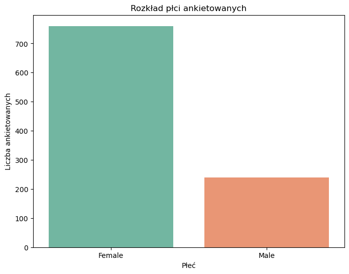

```python
# Ustawienie rozmiaru wykresu na 8x6 cali
plt.figure(figsize=(8,6))

# Obliczenie liczby wystąpień każdej płci w kolumnie 'Gender' (zliczenie wartości unikalnych)
gender_counts = df['Gender'].value_counts()

# Tworzenie wykresu słupkowego z wartościami dla każdej płci
# x=gender_counts.index: etykiety płci (np. 'Male', 'Female')
# y=gender_counts.values: liczby odpowiadające każdej płci
# hue=gender_counts.index: dodanie koloru na podstawie etykiet
# palette='Set2': określenie palety kolorów
sns.barplot(x=gender_counts.index, y=gender_counts.values, hue=gender_counts.index, palette='Set2')

# Dodanie tytułu wykresu
plt.title('Rozkład płci ankietowanych')

# Etykieta osi X
plt.xlabel('Płeć')

# Etykieta osi Y
plt.ylabel('Liczba ankietowanych')

# Wyświetlenie wykresu
plt.show()
```

**Analiza:**

**Dominacja jednej płci:**

*· Liczba ankietowanych kobiet (Female) znacznie przewyższa liczbę mężczyzn (Male). Widać, że kobiet jest ponad 700, podczas gdy mężczyzn jest mniej niż 300.*

**Asymetria w próbie badawczej:**

*· Próba ankietowanych jest nierównomierna pod względem płci, co może wpływać na wyniki badania, jeśli wyniki są zależne od płci.*

**Możliwe wnioski:**

*· Jeśli badanie dotyczyło kwestii, w których płeć odgrywa istotną rolę, należy uwzględnić tę nierównomierność w analizie i interpretacji wyników.* *· Duża nadreprezentacja kobiet może wynikać ze specyfiki badanej grupy lub tematów poruszanych w ankiecie.*

*Podsumowując, dane pokazują znacznie większy udział kobiet w grupie badanej.*

### Wykres rozkładu średniej ocen:

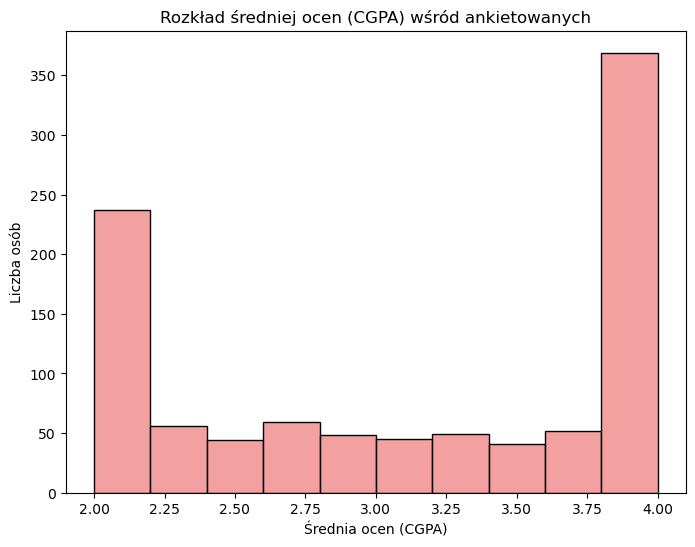

```python
# Ustawienie rozmiaru wykresu na 8x6 cali
plt.figure(figsize=(8,6))

# Tworzenie histogramu dla danych w kolumnie 'CGPA'
# kde=False: wyłączenie gęstości jądra (nie dodajemy krzywej gęstości)
# bins=10: podzielenie danych na 10 przedziałów
# color='lightcoral': ustawienie koloru słupków na jasnoczerwony
sns.histplot(df['CGPA'], kde=False, bins=10, color='lightcoral')

# Dodanie tytułu wykresu
plt.title('Rozkład średniej ocen (CGPA) wśród ankietowanych')

# Etykieta osi X
plt.xlabel('Średnia ocen (CGPA)')

# Etykieta osi Y
plt.ylabel('Liczba osób')

# Wyświetlenie wykresu
plt.show()
```

**Analiza:**

**Dominujące wartości skrajne:**

**Niska liczba osób w średnich przedziałach:**

*· W przedziałach od 2.25 do 3.75 liczba osób jest znacząco mniejsza, co sugeruje, że większość ankietowanych mieści się na dwóch skrajnych końcach skali.*

**Wyraźna asymetria:**

*· Rozkład nie jest równomierny – dominują skrajne wartości, a w środkowej części występuje wyraźna „dolina.”*

**Ogólny wniosek:**

*· Ankietowani należą głównie do dwóch grup: tych, którzy osiągają najwyższe wyniki (4.0) oraz tych, którzy osiągają najniższe (2.0). Może to sugerować duże zróżnicowanie w poziomie osiągnięć.*

*Rozkład ten wskazuje na wyraźne różnice w poziomie wyników, z niewielką reprezentacją osób osiągających średnie oceny.*

### Wykres rozkładu poziomu stresu:

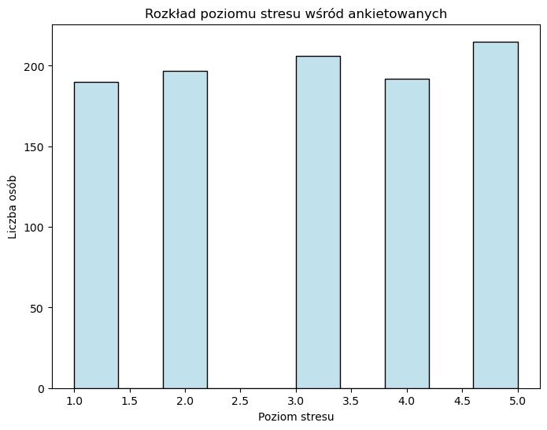

```python
# Ustawienie rozmiaru wykresu na 8x6 cali
plt.figure(figsize=(8,6))

# Tworzenie histogramu dla danych w kolumnie 'StudyStressLevel'
# kde=False: wyłączenie gęstości jądra (nie dodajemy krzywej gęstości)
# bins=10: podzielenie danych na 10 przedziałów
# color='lightblue': ustawienie koloru słupków na jasnoniebieski
sns.histplot(df['StudyStressLevel'], kde=False, bins=10, color='lightblue')

# Dodanie tytułu wykresu
plt.title('Rozkład poziomu stresu wśród ankietowanych')

# Etykieta osi X
plt.xlabel('Poziom stresu')

# Etykieta osi Y
plt.ylabel('Liczba osób')

# Wyświetlenie wykresu
plt.show()
```

**Analiza:**

**Jednolity rozkład:**

*· Wartości liczby osób dla każdego poziomu stresu są bardzo zbliżone, co wskazuje na równomierny rozkład poziomów stresu w badanej grupie.*

**Największa liczba osób:**

*· Najwięcej osób zadeklarowało poziom stresu na poziomie 5 (ponad 200 osób), co sugeruje, że dla części badanych stres jest bardzo wysoki.*

**Równa liczba respondentów:**

*· Liczba osób w poszczególnych kategoriach stresu różni się tylko nieznacznie, co wskazuje na brak wyraźnej dominacji żadnego poziomu.*

**Ogólny wniosek:**

*· Badana grupa doświadcza różnorodnych poziomów stresu, ale poziom stresu 5 jest najczęściej deklarowany.*

*Można zauważyć, że stres w tej grupie jest dość zróżnicowany, jednak wielu ankietowanych odczuwa stres na najwyższym poziomie.*

### Wykres rozkładu liczby godzin:

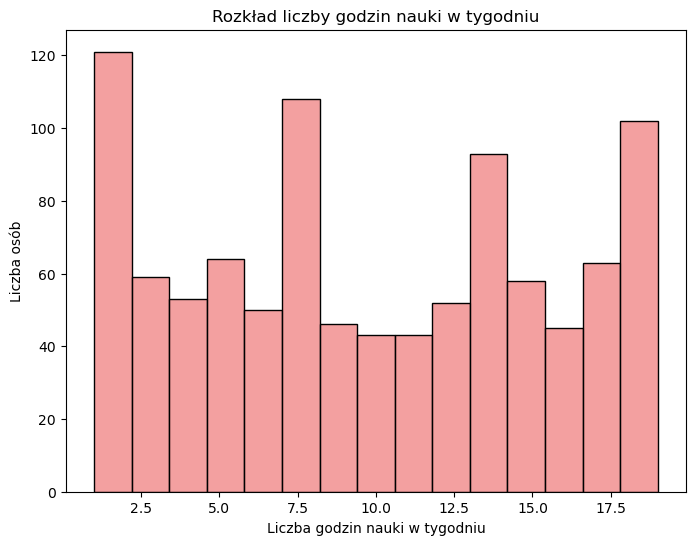

```python
# Ustawienie rozmiaru wykresu na 8x6 cali
plt.figure(figsize=(8,6))

# Tworzenie histogramu dla danych w kolumnie 'StudyHoursPerWeek'
# kde=False: wyłączenie gęstości jądra (nie dodajemy krzywej gęstości)
# bins=15: podzielenie danych na 15 przedziałów
# color='lightcoral': ustawienie koloru słupków na jasnoczerwony
sns.histplot(df['StudyHoursPerWeek'], kde=False, bins=15, color='lightcoral')

# Dodanie tytułu wykresu
plt.title('Rozkład liczby godzin nauki w tygodniu')

# Etykieta osi X
plt.xlabel('Liczba godzin nauki w tygodniu')

# Etykieta osi Y
plt.ylabel('Liczba osób')

# Wyświetlenie wykresu
plt.show()
```

**Analiza:**

**Największa liczba osób:**

**Najmniejsza liczba osób:**

*· W przedziałach około 10–12,5 godziny tygodniowo liczba osób jest najniższa (poniżej 50).*

**Wyraźne skrajności:**

**Rozkład nierównomierny:**

*· Rozkład godzin nauki jest daleki od równomiernego – w niektórych przedziałach liczba osób jest kilkukrotnie wyższa niż w innych.*

### Wykres porównania posiadania ataków paniki między kobietami, a mężczyznami:

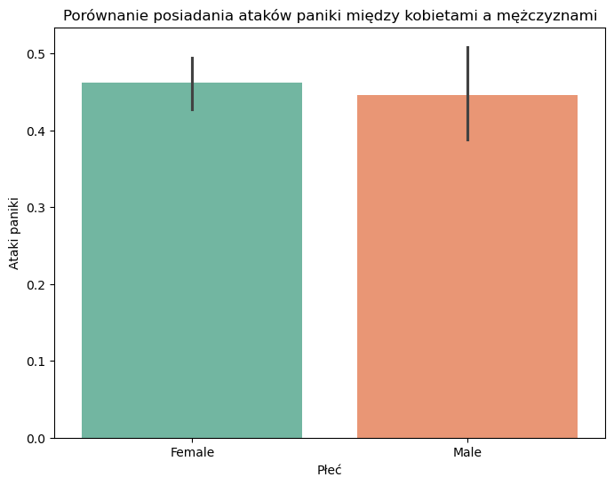

```python
# Ustawienie rozmiaru wykresu na 8x6 cali
plt.figure(figsize=(8,6))

# Tworzenie wykresu słupkowego do porównania wartości w kolumnie 'PanicAttack' dla każdej płci
# x='Gender': Oś X reprezentuje płeć (np. 'Male', 'Female')
# y='PanicAttack': Oś Y reprezentuje średnią wartość dla kolumny 'PanicAttack'
# data=df: Dane pochodzą z DataFrame o nazwie 'df'
# hue='Gender': Kolory słupków są różnicowane według płci
# palette='Set2': Ustawienie estetycznej palety kolorów
sns.barplot(x='Gender', y='PanicAttack', data=df, hue='Gender', palette='Set2')

# Dodanie tytułu wykresu
plt.title('Porównanie posiadania ataków paniki między kobietami a mężczyznami')

# Etykieta osi X
plt.xlabel('Płeć')

# Etykieta osi Y
plt.ylabel('Ataki paniki')

# Wyświetlenie wykresu
plt.show()
```

**Analiza:**

**Średni poziom ataków paniki:**

*· Kobiety (Female): Średni poziom ataków paniki jest nieco wyższy niż u mężczyzn, choć różnica jest niewielka.* *· Mężczyźni (Male): Średni poziom ataków paniki jest trochę niższy niż u kobiet.*

**Przedziały błędu:**

**Podobieństwo między płciami:**

*· Różnica między kobietami a mężczyznami jest mała, co sugeruje, że ataki paniki występują z podobną częstotliwością w obu grupach.*

**Mała różnica między płciami:**

*· Chociaż kobiety wykazują nieco wyższy poziom ataków paniki niż mężczyźni, różnica jest niewielka i niekoniecznie statystycznie istotna.*

**Podobne doświadczenia emocjonalne:**

*· Wyniki sugerują, że zarówno kobiety, jak i mężczyźni mogą być w podobnym stopniu narażeni na ataki paniki, co wskazuje na potrzebę wsparcia obu grup.*

### Wykres zależności średniej ocen od liczby godzin nauki:

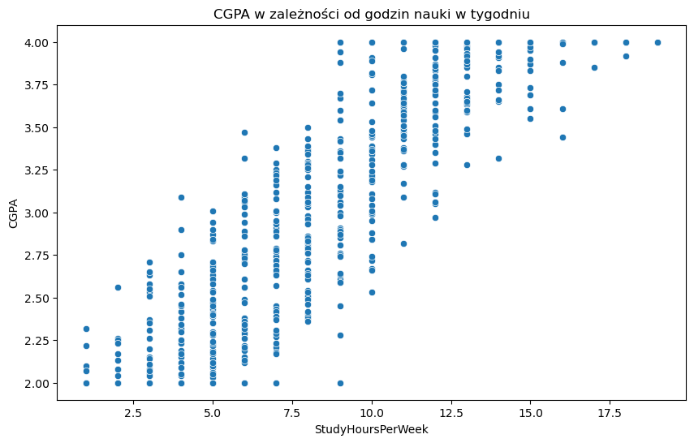

```python
# Ustawienie rozmiaru wykresu na 10x6 cali
plt.figure(figsize=(10,6))

# Tworzenie wykresu punktowego (scatter plot)
# x='StudyHoursPerWeek': Oś X reprezentuje liczbę godzin nauki w tygodniu
# y='CGPA': Oś Y reprezentuje średnią ocen (CGPA)
# data=df: Dane pochodzą z DataFrame o nazwie 'df'
sns.scatterplot(x='StudyHoursPerWeek', y='CGPA', data=df)

# Dodanie tytułu wykresu
plt.title('CGPA w zależności od godzin nauki w tygodniu')

# Wyświetlenie wykresu
plt.show()
```

**Analiza:**

**Trend rosnący:**

*· Widać wyraźną zależność: im więcej godzin nauki w tygodniu, tym wyższa średnia ocen (CGPA).* *· To sugeruje, że liczba godzin poświęcanych na naukę ma pozytywny wpływ na wyniki akademickie.*

**Dolna granica CGPA:**

*· Nawet przy niewielkiej liczbie godzin nauki w tygodniu (np. poniżej 5), CGPA wynosi co najmniej 2.0, co wskazuje, że minimalny poziom nauki może być wystarczający do osiągnięcia umiarkowanych wyników.*

**Górna granica CGPA:**

**Zróżnicowanie danych:**

**Efektywność:**

*· Po około 15 godzinach nauki tygodniowo wyniki CGPA osiągają swoje maksimum (4.0), co może wskazywać, że dodatkowy czas nauki nie prowadzi już do wyraźnych korzyści.*

**Pozytywna korelacja:**

*· Im więcej czasu poświęca się na naukę, tym wyższa średnia ocen. Jest to zgodne z intuicją, że więcej czasu na naukę pozwala lepiej przyswoić materiał.*

**Optymalny poziom nauki:**

**Minimalny próg:**

*· Nawet przy niewielkiej liczbie godzin nauki (np. 2-5 godzin tygodniowo) można osiągnąć umiarkowane wyniki, ale średnia ocen jest bardziej zróżnicowana.*

### Wykresy zależności chorób od kierunku studiów:

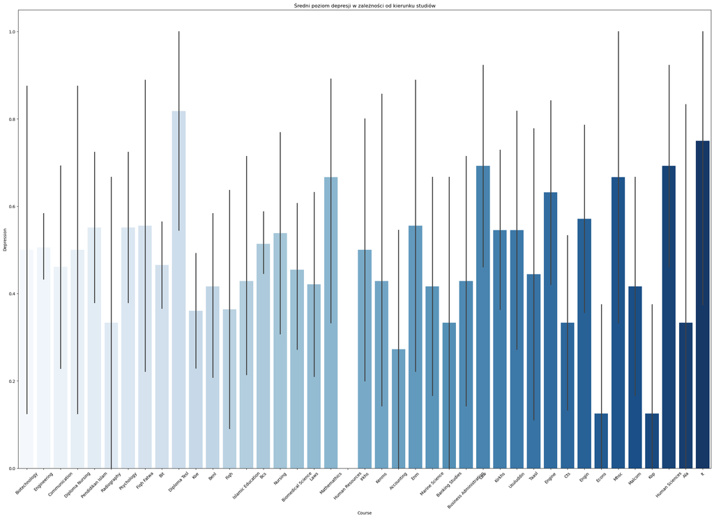

```python
# Ustawienie rozmiaru wykresu na 30x20 cali
plt.figure(figsize=(30,20))

# Tworzenie wykresu słupkowego pokazującego średni poziom depresji dla różnych kierunków studiów
# x='Course': Oś X reprezentuje kierunki studiów
# y='Depression': Oś Y reprezentuje średni poziom depresji
# data=df: Dane pochodzą z DataFrame o nazwie 'df'
# palette="Blues": Ustawienie kolorystyki na odcienie niebieskiego
# hue='Course': Dodanie kolorowego podziału na podstawie kierunków studiów (opcjonalne, może być nadmiarowe w tym przypadku)
sns.barplot(x='Course', y='Depression', data=df, palette="Blues", hue='Course')

# Dodanie tytułu wykresu
plt.title('Średni poziom depresji w zależności od kierunku studiów')

# Obrócenie etykiet na osi X o 45 stopni, aby poprawić czytelność
plt.xticks(rotation=45)

# Wyświetlenie wykresu
plt.show()
```

**Analiza:**

**Kierunki o najwyższym poziomie depresji:**

**Kierunki o najniższym poziomie depresji:**

**Zróżnicowanie wyników:**

**Ogólne trendy:**

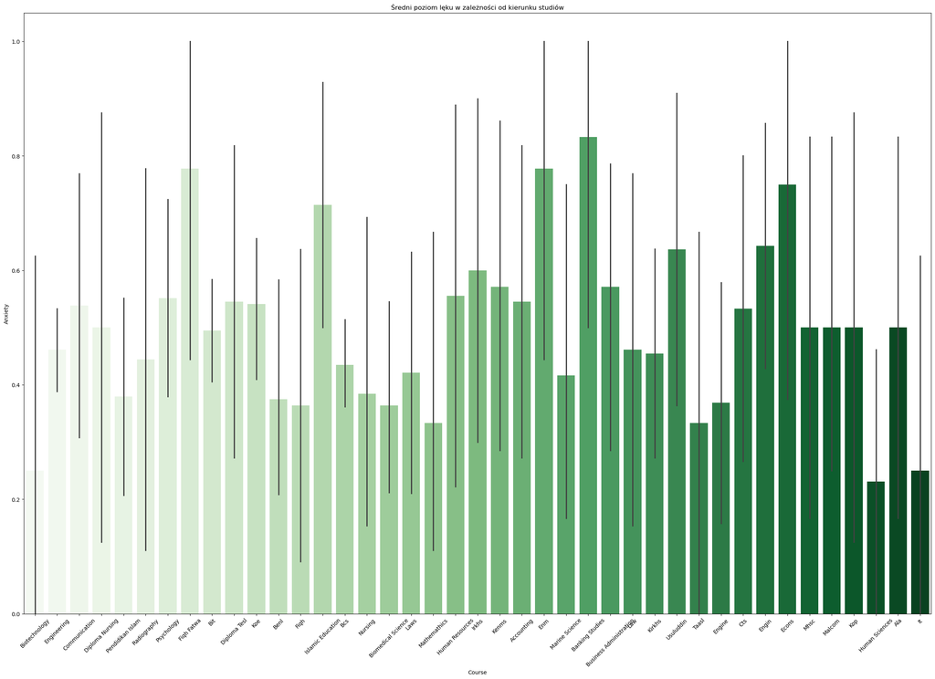

```python
# Ustawienie rozmiaru wykresu na 30x20 cali
plt.figure(figsize=(30,20))

# Tworzenie wykresu słupkowego pokazującego średni poziom lęku dla różnych kierunków studiów
# x='Course': Oś X reprezentuje kierunki studiów
# y='Anxiety': Oś Y reprezentuje średni poziom lęku
# data=df: Dane pochodzą z DataFrame o nazwie 'df'
# palette="Greens": Ustawienie kolorystyki na odcienie zielonego
# hue='Course': Dodanie kolorowego podziału na podstawie kierunków studiów (opcjonalne, może być nadmiarowe w tym przypadku)
sns.barplot(x='Course', y='Anxiety', data=df, palette="Greens", hue='Course')

# Dodanie tytułu wykresu
plt.title('Średni poziom lęku w zależności od kierunku studiów')

# Obrócenie etykiet na osi X o 45 stopni, aby poprawić czytelność
plt.xticks(rotation=45)

# Wyświetlenie wykresu
plt.show()
```

**Analiza:**

**Kierunki o najwyższym poziomie lęku:**

**Kierunki o najniższym poziomie lęku:**

**Zróżnicowanie wyników:**

**Ogólne trendy:**

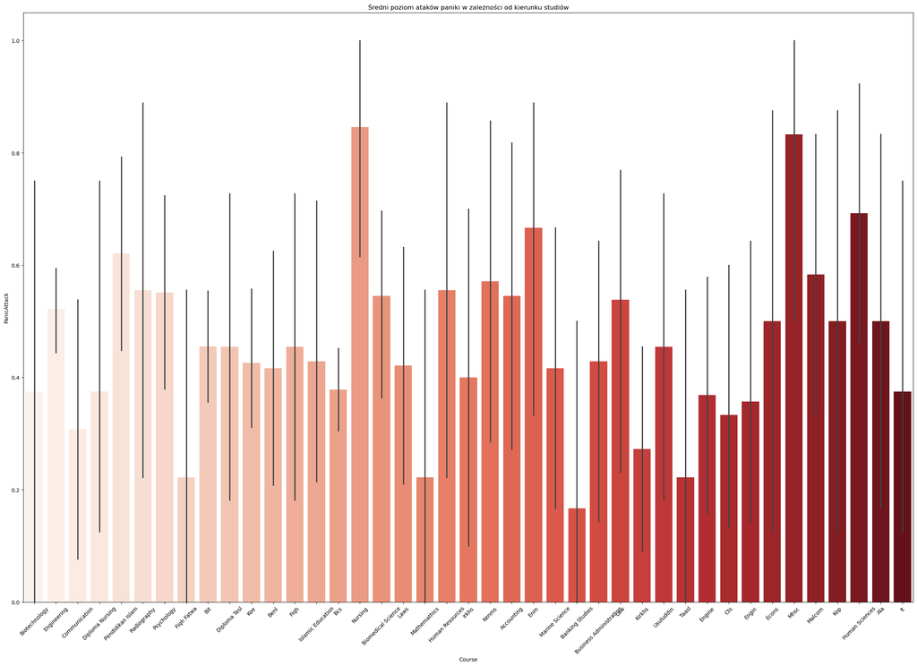

```python
# Ustawienie rozmiaru wykresu na 30x20 cali
plt.figure(figsize=(30,20))

# Tworzenie wykresu słupkowego pokazującego średni poziom ataków paniki dla różnych kierunków studiów
# x='Course': Oś X reprezentuje kierunki studiów
# y='PanicAttack': Oś Y reprezentuje średni poziom ataków paniki
# data=df: Dane pochodzą z DataFrame o nazwie 'df'
# palette="Reds": Ustawienie kolorystyki na odcienie czerwonego
# hue='Course': Dodanie kolorowego podziału na podstawie kierunków studiów (opcjonalne, może być nadmiarowe w tym przypadku)
sns.barplot(x='Course', y='PanicAttack', data=df, palette="Reds", hue='Course')

# Dodanie tytułu wykresu
plt.title('Średni poziom ataków paniki w zależności od kierunku studiów')

# Obrócenie etykiet na osi X o 45 stopni, aby poprawić czytelność
plt.xticks(rotation=45)

# Wyświetlenie wykresu
plt.show()
```

**Analiza:**

**Najwyższe poziomy ataków paniki:**

**Najniższe poziomy ataków paniki:**

**Zróżnicowanie wyników:**

**Ogólne trendy:**

### Wykres pudełkowy zależności objawów od wsparcia:

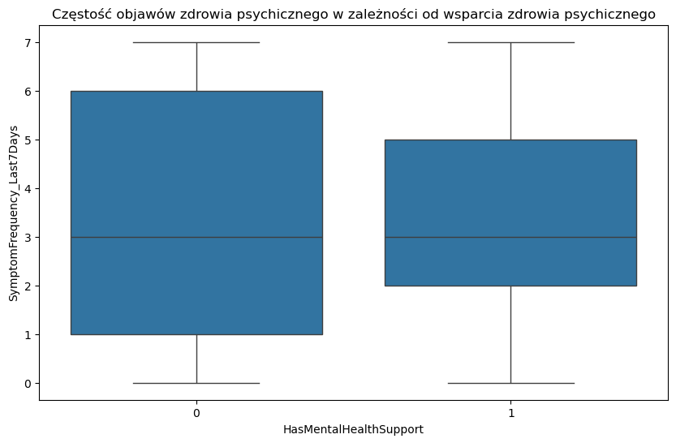

```python
# Ustawienie rozmiaru wykresu na 10x6 cali
plt.figure(figsize=(10,6))

# Tworzenie wykresu skrzynkowego (box plot) dla zależności między wsparciem zdrowia psychicznego a częstotliwością objawów
# x='HasMentalHealthSupport': Oś X reprezentuje dostępność wsparcia zdrowia psychicznego (np. "Tak" lub "Nie")
# y='SymptomFrequency_Last7Days': Oś Y reprezentuje częstość występowania objawów zdrowia psychicznego w ciągu ostatnich 7 dni
# data=df: Dane pochodzą z DataFrame o nazwie 'df'
sns.boxplot(x='HasMentalHealthSupport', y='SymptomFrequency_Last7Days', data=df)

# Dodanie tytułu wykresu
plt.title('Częstość objawów zdrowia psychicznego w zależności od wsparcia zdrowia psychicznego')

# Wyświetlenie wykresu
plt.show()
```

**Analiza:**

**Osoby bez wsparcia psychicznego (0):**

**Osoby korzystające ze wsparcia psychicznego (1):**

### Wykres procentu studentów z wsparciem zdrowia psychicznego:

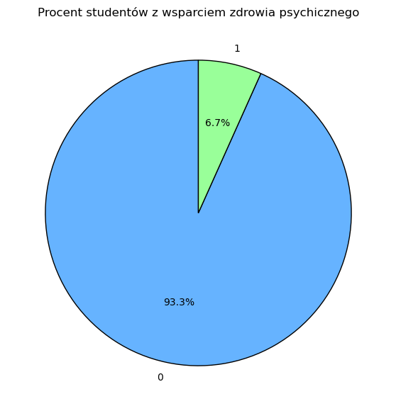

```python
# Obliczenie procentowego udziału studentów z i bez wsparcia zdrowia psychicznego
# value_counts(normalize=True): Zlicza wystąpienia wartości w kolumnie i normalizuje je (procentowy udział)
# * 100: Przeliczenie na procenty
support_percentage = df['HasMentalHealthSupport'].value_counts(normalize=True) * 100

# Tworzenie wykresu kołowego
plt.figure(figsize=(7, 7))  # Ustawienie rozmiaru wykresu na 7x7 cali
support_percentage.plot.pie(
    autopct='%1.1f%%',  # Wyświetlanie procentów z dokładnością do jednego miejsca po przecinku
    colors=['#66b3ff', '#99ff99'],  # Ustawienie kolorów dla poszczególnych grup
    startangle=90,  # Rozpoczęcie rysowania od 90 stopni (pozycja na górze)
    wedgeprops={'edgecolor': 'black'}  # Dodanie czarnej obramówki do klinów wykresu
)

# Dodanie tytułu wykresu
plt.title('Procent studentów z wsparciem zdrowia psychicznego')

# Usunięcie etykiety osi Y (jest zbędna w przypadku wykresu kołowego)
plt.ylabel('')

# Wyświetlenie wykresu
plt.show()
```

**Analiza:**

**Studenci bez wsparcia zdrowia psychicznego (wartość 0):**

*· 93,3% studentów nie korzysta z żadnej formy wsparcia psychicznego.* *· Jest to zdecydowana większość grupy.*

**Studenci korzystający ze wsparcia zdrowia psychicznego (wartość 1):**

*· Tylko 6,7% studentów korzysta z pomocy w zakresie zdrowia psychicznego.* *· Jest to bardzo mały odsetek w porównaniu do całej grupy.*

**Większość studentów (ponad 93%) nie korzysta z dostępnych form wsparcia psychicznego, co może sugerować, że:**

*· Brakuje świadomości na temat dostępnych usług.* *· Istnieją bariery, które utrudniają studentom dostęp do wsparcia (np. koszty, brak czasu, obawa przed stygmatyzacją).* *· Niektórzy studenci mogą nie odczuwać potrzeby korzystania z takiej pomocy.*

### Macierz korelacji średniej ocen, poziomu stresu oraz chorób:

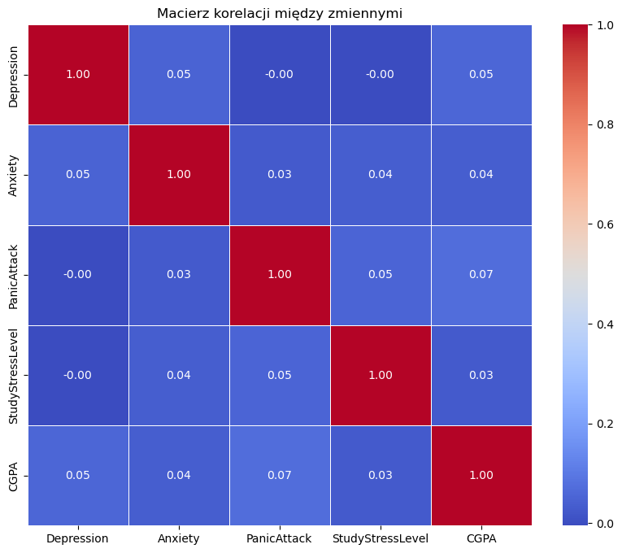

```python
# Obliczanie macierzy korelacji dla wybranych zmiennych
# corr(): Oblicza współczynniki korelacji (Pearsona) między zmiennymi
correlation = df[['Depression', 'Anxiety', 'PanicAttack', 'StudyStressLevel', 'CGPA']].corr()

# Tworzenie heatmapy (mapy cieplnej) w celu wizualizacji macierzy korelacji
plt.figure(figsize=(10, 8))  # Ustawienie rozmiaru wykresu na 10x8 cali
sns.heatmap(
    correlation,  # Macierz korelacji jako dane wejściowe
    annot=True,  # Wyświetlanie wartości korelacji na heatmapie
    cmap='coolwarm',  # Ustawienie palety kolorów: od niebieskiego (ujemna korelacja) do czerwonego (dodatnia korelacja)
    fmt='.2f',  # Formatowanie wartości korelacji z dokładnością do 2 miejsc po przecinku
    linewidths=0.5  # Dodanie odstępów między komórkami siatki
)

# Dodanie tytułu wykresu
plt.title('Macierz korelacji między zmiennymi')

# Wyświetlenie wykresu
plt.show()
```

**Analiza:**

**Macierz korelacji przedstawia związki między zmiennymi. Wartości korelacji mogą wynosić od -1 do 1:**

*· 1: silna dodatnia korelacja (obie zmienne rosną jednocześnie).* *· 0: brak korelacji.* *· -1: silna ujemna korelacja (jedna zmienna rośnie, druga maleje).*

**Depresja (Depression):**

*· Depresja vs Lęk (Anxiety): Korelacja wynosi 0.05 – bardzo słaba dodatnia korelacja, czyli osoby z objawami depresji mogą minimalnie częściej doświadczać lęku.* *· Depresja vs Ataki paniki (PanicAttack): Korelacja wynosi -0.00 – brak związku między depresją a atakami paniki.* *· Depresja vs Poziom stresu związanego z nauką (StudyStressLevel): Korelacja wynosi -0.00 – brak związku.* *· Depresja vs Średnia ocen (CGPA): Korelacja wynosi 0.05 – bardzo słaby pozytywny związek, co oznacza, że poziom depresji nie wpływa znacząco na średnią ocen.*

**Lęk (Anxiety):**

*· Lęk vs Ataki paniki (PanicAttack): Korelacja wynosi 0.03 – brak istotnej korelacji między lękiem a atakami paniki.* *· Lęk vs Poziom stresu związanego z nauką (StudyStressLevel): Korelacja wynosi 0.04 – bardzo słaba dodatnia korelacja, co może sugerować, że osoby odczuwające lęk minimalnie częściej zgłaszają wyższy poziom stresu związanego z nauką.* *· Lęk vs Średnia ocen (CGPA): Korelacja wynosi 0.04 – brak istotnego związku między lękiem a wynikami w nauce.*

**Ataki paniki (PanicAttack):**

*· Ataki paniki vs Poziom stresu związanego z nauką (StudyStressLevel): Korelacja wynosi 0.05 – bardzo słaby pozytywny związek, co może oznaczać, że osoby doświadczające ataków paniki minimalnie częściej odczuwają stres związany z nauką.* *· Ataki paniki vs Średnia ocen (CGPA): Korelacja wynosi 0.07 – brak istotnego związku.*

**Poziom stresu związanego z nauką (StudyStressLevel):**

*· Poziom stresu vs Średnia ocen (CGPA): Korelacja wynosi 0.03 – brak znaczącej korelacji między stresem związanym z nauką a wynikami w nauce.*

### Średni poziom depresji, lęku i ataków paniki w zależności od płci:

```python
# Grupowanie danych według płci ('Gender') i obliczanie średnich wartości dla zmiennych
# 'Depression', 'Anxiety', 'PanicAttack'
health_symptoms_by_gender = df.groupby('Gender')[['Depression', 'Anxiety', 'PanicAttack']].mean()

# Wyświetlenie obliczonych średnich wartości w podziale na płeć
print(health_symptoms_by_gender)
```

```
        Depression   Anxiety  PanicAttack
Gender
Female    0.494737  0.472368     0.461842
Male      0.445833  0.479167     0.445833
```

**Analiza:**

**Depresja:**

*· Kobiety (Female): Średni poziom wynosi 0.494737.* *· Mężczyźni (Male): Średni poziom wynosi 0.445833.* *· Wnioski: Kobiety wykazują nieco wyższy średni poziom depresji w porównaniu do mężczyzn.*

**Lęk (Anxiety):**

*· Kobiety (Female): Średni poziom wynosi 0.472368.* *· Mężczyźni (Male): Średni poziom wynosi 0.479167.* *· Wnioski: Mężczyźni mają minimalnie wyższy poziom lęku w porównaniu do kobiet.*

**Ataki paniki (PanicAttack):**

*· Kobiety (Female): Średni poziom wynosi 0.461842.* *· Mężczyźni (Male): Średni poziom wynosi 0.445833.* *· Wnioski: Kobiety doświadczają nieco wyższego średniego poziomu ataków paniki niż mężczyźni.*

*Kobiety: Wykazują wyższy poziom depresji i ataków paniki w porównaniu do mężczyzn. Mężczyźni: Mają minimalnie wyższy średni poziom lęku. Różnice między płciami są niewielkie, ale wskazują na potrzebę zróżnicowanego podejścia do wsparcia zdrowia psychicznego w zależności od płci.*

### Średni poziom stresu w nauce w zależności od roku studiów:

```python
# Grupowanie danych według roku studiów ('YearOfStudy') i obliczanie średniego poziomu stresu z nauki ('StudyStressLevel')
stress_by_year = df.groupby('YearOfStudy')['StudyStressLevel'].mean()

# Wyświetlenie średnich poziomów stresu z nauki dla każdego roku studiów
print(stress_by_year)
```

```
YearOfStudy
Year 1    3.019417
Year 2    3.054745
Year 3    3.070833
Year 4    3.067568
Name: StudyStressLevel, dtype: float64
```

**Analiza:**

**Year 1 (Pierwszy rok):**

*· Średni poziom stresu wynosi 3.02.* *· Jest to najniższy poziom w porównaniu do innych lat.*

**Year 2 (Drugi rok):**

*· Średni poziom stresu wzrasta do 3.05.* *· Możliwa przyczyna: więcej obowiązków akademickich i trudniejszy materiał w porównaniu do pierwszego roku.*

**Year 3 (Trzeci rok):**

*· Średni poziom stresu wynosi 3.07.* *· Wzrost może wynikać z rosnącej presji związanej z przygotowaniami do egzaminów końcowych, praktyk lub prac dyplomowych.*

**Year 4 (Czwarty rok):**

*· Średni poziom stresu wynosi 3.07, co jest porównywalne z trzecim rokiem.* *· Możliwe, że studenci na ostatnim roku są pod presją ukończenia studiów, pracy dyplomowej oraz poszukiwania pracy.*

*Najniższy poziom stresu jest obserwowany wśród studentów na pierwszym roku, co może być związane z mniejszą liczbą trudnych przedmiotów i bardziej ogólnym charakterem studiów. Poziom stresu wzrasta od drugiego roku, osiągając wyższy poziom na trzecim i czwartym roku, co może wynikać z większej odpowiedzialności, trudniejszych zajęć, przygotowań do końcowego etapu studiów oraz dodatkowych zobowiązań.*

### Sprawdzenie liczby studentów danych wytycznych:

```python
# Liczba studentów z różnymi poziomami depresji
# value_counts(normalize=True): Zlicza wystąpienia każdego poziomu depresji i normalizuje je (procentowy udział)
# * 100: Przeliczenie udziałów na procenty
depression_counts = df['Depression'].value_counts(normalize=True) * 100
print(depression_counts)

# Liczba studentów z różnymi poziomami lęku
# Podobnie jak dla depresji, obliczamy procentowy udział dla poziomu lęku
anxiety_counts = df['Anxiety'].value_counts(normalize=True) * 100
print(anxiety_counts)

# Liczba studentów z różnymi poziomami ataków paniki
# Podobne działanie dla zmiennej ataków paniki
panic_attack_counts = df['PanicAttack'].value_counts(normalize=True) * 100
print(panic_attack_counts)
```

```
Depression
0    51.7
1    48.3
Name: proportion, dtype: float64
Anxiety
0    52.6
1    47.4
Name: proportion, dtype: float64
PanicAttack
0    54.2
1    45.8
Name: proportion, dtype: float64
```

**Analiza:**

**Depresja:**

*· 51,7% studentów nie ma objawów depresji (wartość 0).* *· 48,3% studentów ma objawy depresji (wartość 1).* *Wynika z tego, że prawie połowa badanych studentów doświadcza objawów depresji, co wskazuje na wysoki poziom tego problemu w grupie.*

**Lęk (Anxiety):**

*· 52,6% studentów nie odczuwa lęku (wartość 0).* *· 47,4% studentów odczuwa lęk (wartość 1).* *Podobnie jak w przypadku depresji, poziom lęku jest wysoki i dotyka prawie połowy badanych.*

**Ataki paniki (PanicAttack):**

*· 54,2% studentów nie doświadcza ataków paniki (wartość 0).* *· 45,8% studentów doświadcza ataków paniki (wartość 1).*